# Comprehensive Competing-Risks Analysis with ml4time2event

ml4time2event team

2025-12-14

# Overview

The competing-risks path mirrors the survival UX introduced in the refactor: build a task, fit registered engines, obtain tidy predictions/metrics, and visualise or explain with standard verbs. This vignette illustrates the workflow on the classic bone marrow transplant (BMT) dataset.

# 1. Packages and data

```r
library(ml4time2event)
library(dplyr)
library(ggplot2)
```

`get_bmt_competing_risks_data()` returns the prepared dataset that was used in the legacy API. We only need to split the multi-class status into a binary event flag plus a separate cause column.

```r
bmt_raw <- get_bmt_competing_risks_data()

bmt_df <- bmt_raw |>
  mutate(
    cause = if_else(status == 0L, NA_integer_, status),
    status = if_else(status == 0L, 0L, 1L)
  )

glimpse(bmt_df)
```

```
## Rows: 177
## Columns: 8
## $ sex    <fct> M, F, M, F, F, M, M, F, M, F, M, M, F, M, M, F, M, M, M, M, F, …
## $ d      <fct> ALL, AML, ALL, ALL, ALL, ALL, ALL, ALL, ALL, ALL, ALL, AML, AML…
## $ phase  <fct> Relapse, CR2, CR3, CR2, CR2, Relapse, CR1, CR1, CR1, Relapse, R…
## $ age    <int> 48, 23, 7, 26, 36, 17, 7, 17, 26, 8, 29, 13, 29, 7, 40, 20, 18,…
## $ status <int> 1, 1, 0, 1, 1, 1, 0, 1, 0, 1, 1, 1, 1, 1, 1, 1, 0, 1, 1, 1, 1, …
## $ source <fct> BM+PB, BM+PB, BM+PB, BM+PB, BM+PB, BM+PB, BM+PB, BM+PB, BM+PB, …
## $ ftime  <dbl> 0.67, 9.50, 131.77, 24.03, 1.47, 2.23, 124.83, 10.53, 123.90, 2…
## $ cause  <int> 2, 1, NA, 2, 2, 2, NA, 2, NA, 1, 2, 2, 2, 1, 2, 2, NA, 2, 2, 2,…
```

```r
table(bmt_df$status, useNA = "ifany")
```

```
##
##   0   1
##  46 131
```

Create a simple hold-out split for validation.

```r
set.seed(123)
train_rows <- sample.int(nrow(bmt_df), size = floor(0.7 * nrow(bmt_df)))
bmt_train <- bmt_df[train_rows, ]
bmt_test <- bmt_df[-train_rows, ]

sprintf(
  "Training rows: %s  |  Validation rows: %s",
  nrow(bmt_train), nrow(bmt_test)
)
```

```
## [1] "Training rows: 123  |  Validation rows: 54"
```

# 2. Build a competing-risk task

```r
cr_task <- ml4t2e_task_cr(
  data = bmt_train,
  time = "ftime",
  status = "status",
  cause = "cause",
  features = c("sex", "d", "phase", "age", "source"),
  time_units = "years"
)
```

The task stores the time range, the cause mapping, and the feature set that downstream engines rely upon.

# 3. Fit registered engines (with ensembling)

The registry exposes a consistent set of engine identifiers; you can list them via `ml4t2e_list_models("competing_risk")`.

```r
ml4t2e_list_models("competing_risk")
```

```
##              engine        outcome                        label     packages
## 1           cr_bart competing_risk          BART Competing Risk         BART
## 2               cox competing_risk           Cause-specific Cox     survival
## 3      cr_fine_gray competing_risk                    Fine-Gray   fastcmprsk
## 4            cr_gam competing_risk           GAM Competing Risk         mgcv
## 5  cr_random_forest competing_risk Random Forest Competing Risk randomFo....
## 6        cr_rulefit competing_risk       RuleFit Competing Risk rpart, p....
## 7      cr_shallownn competing_risk    Shallow NN Competing Risk
## 8        cr_survreg competing_risk    Parametric Competing Risk     survival
## 9           cr_ttah competing_risk          TTAH Competing Risk         nnet
## 10       cr_xgboost competing_risk       XGBoost Competing Risk      xgboost
##            tags
## 1  bart, co....
## 2  cox, com....
## 3  semi-par....
## 4  smooth, ....
## 5  random-f....
## 6  rules, t....
## 7  neural-n....
## 8    parametric
## 9  semipara....
## 10 xgboost,....
```

```r
cr_fit <- ml4t2e_fit(
  task = cr_task,
  models = c("cox", "cr_fine_gray", "cr_random_forest", "cr_shallownn", "cr_ttah"),
  ensemble = "auto",
  controls = list(times = seq(0, 120, length.out = 60))
)

cr_fit
```

```
## <t2e_fit>
##  outcome: competing_risk
##  models : cox, cr_fine_gray, cr_random_forest, cr_shallownn, cr_ttah, ensemble
##  time grid points: 60
##  created: 2025-12-14 14:08:28 EST
```

Training metrics are again a single function call away.

```r
ml4t2e_evaluate(
  cr_fit,
  metrics = c("c_index", "ibs"),
  include = c("ensemble", "cox", "cr_fine_gray", "cr_random_forest", "cr_shallownn", "cr_ttah")
)
```

```
##            model cause  metric     value
## 1       ensemble     1     ibs 0.1369615
## 2       ensemble     1 c_index 0.8555054
## 3       ensemble     2     ibs 0.1685895
## 4       ensemble     2 c_index 0.8131868
## 5            cox     1     ibs 0.1716729
## 6            cox     1 c_index 0.7566704
## 7            cox     2     ibs 0.2182117
## 8            cox     2 c_index 0.6681796
## 9      fine_gray     1     ibs 0.1696255
## 10     fine_gray     1 c_index 0.7540398
## 11     fine_gray     2     ibs 0.2183070
## 12     fine_gray     2 c_index 0.6643574
## 13 random_forest     1     ibs 0.1910251
## 14 random_forest     1 c_index 0.6245772
## 15 random_forest     2     ibs 0.2364154
## 16 random_forest     2 c_index 0.5648591
## 17     shallownn     1     ibs 0.1300139
## 18     shallownn     1 c_index 0.8970312
## 19     shallownn     2     ibs 0.1572735
## 20     shallownn     2 c_index 0.8575012
## 21          ttah     1     ibs 0.1570353
## 22          ttah     1 c_index 0.7641864
## 23          ttah     2     ibs 0.1951186
## 24          ttah     2 c_index 0.7111801
```

# 4. Score a hold-out set

```r
cr_task_val <- ml4t2e_task_cr(
  data = bmt_test,
  time = "ftime",
  status = "status",
  cause = "cause",
  features = c("sex", "d", "phase", "age", "source"),
  time_units = "years"
)

cr_preds_val <- predict(
  cr_fit,
  newdata = bmt_test,
  times = seq(0, 120, length.out = 60),
  type = "cif",
  include = c("ensemble", "cox", "fine_gray", "cr_random_forest", "cr_shallownn", "cr_ttah")
)

ml4t2e_evaluate(
  cr_preds_val,
  task = cr_task_val,
  metrics = c("c_index", "ibs")
)
```

```
##            model cause  metric     value
## 1       ensemble     1     ibs 0.2648209
## 2       ensemble     1 c_index 0.6480583
## 3       ensemble     2     ibs 0.2363123
## 4       ensemble     2 c_index 0.5942029
## 5            cox     1     ibs 0.2333162
## 6            cox     1 c_index 0.6577670
## 7            cox     2     ibs 0.2457078
## 8            cox     2 c_index 0.5335968
## 9  random_forest     1     ibs 0.2349706
## 10 random_forest     1 c_index 0.4927184
## 11 random_forest     2     ibs 0.2303771
## 12 random_forest     2 c_index 0.6126482
## 13     shallownn     1     ibs 0.3675995
## 14     shallownn     1 c_index 0.6229773
## 15     shallownn     2     ibs 0.2645295
## 16     shallownn     2 c_index 0.5718050
## 17          ttah     1     ibs 0.2754929
## 18          ttah     1 c_index 0.6221683
## 19          ttah     2     ibs 0.2657113
## 20          ttah     2 c_index 0.5283267
```

# 5. Visualise cumulative incidence curves

`autoplot()` aggregates model-specific CIFs across individuals and separates them by cause.

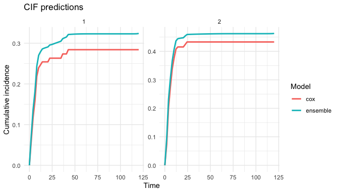

```r
autoplot(cr_fit, include = c("ensemble", "cox", "cr_random_forest", "cr_shallownn", "cr_ttah"))
```

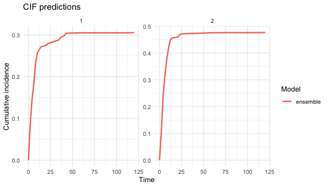

```r
autoplot(cr_preds_val, include = "ensemble")
```

# 6. Pipelines with preprocessing and resampling

```r
library(recipes)
library(rsample)

cr_pipeline <- ml4t2e_pipeline(
  outcome = list(
    type = "competing_risk",
    time = "ftime",
    status = "status",
    cause = "cause"
  ),
  models = c("cox", "cr_fine_gray", "cr_random_forest", "cr_shallownn", "cr_ttah"),
  ensemble = "auto",
  recipe = recipe(status ~ ., data = bmt_train) |>
    step_impute_median(all_numeric_predictors()) |>
    step_dummy(all_nominal_predictors()),
  resampling = vfold_cv(bmt_train, v = 3)
)

cr_pipeline$fit(bmt_train)
cr_pipeline$summary()
```

```
## $outcome
## $outcome$type
## [1] "competing_risk"
##
## $outcome$time
## [1] "ftime"
##
## $outcome$status
## [1] "status"
##
## $outcome$cause
## [1] "cause"
##
##
## $models
```

[output cut: 111 more lines]

Evaluating on the validation set reuses the same helper:

```r
cr_pipeline$evaluate(
  newdata = bmt_test,
  metrics = c("c_index", "ibs"),
  include = "ensemble"
)
```

```
##      model cause  metric     value
## 1 ensemble     1     ibs 0.2198017
## 2 ensemble     1 c_index 0.6577670
## 3 ensemble     2     ibs 0.2414371
## 4 ensemble     2 c_index 0.5467721
```

Predictions are tidy tibbles, ready for `dplyr` or `ggplot2`.

```r
cr_pipeline$predict(
  newdata = bmt_test[1:4, ],
  times = seq(0, 60, by = 6),
  type = "cif",
  include = "ensemble"
)
```

```
## # A tibble: 88 × 7
##       id  time cause   cif model    ensemble set
##    <int> <dbl> <chr> <dbl> <chr>    <lgl>    <chr>
##  1     1     0 1     0     ensemble TRUE     test
##  2     1     6 1     0.101 ensemble TRUE     test
##  3     1    12 1     0.144 ensemble TRUE     test
##  4     1    18 1     0.148 ensemble TRUE     test
##  5     1    24 1     0.150 ensemble TRUE     test
##  6     1    30 1     0.150 ensemble TRUE     test
##  7     1    36 1     0.153 ensemble TRUE     test
##  8     1    42 1     0.155 ensemble TRUE     test
##  9     1    48 1     0.157 ensemble TRUE     test
## 10     1    54 1     0.157 ensemble TRUE     test
## # ℹ 78 more rows
```

# 7. Persist fitted objects

Use `ml4t2e_save()` / `ml4t2e_load()` for `t2e_fit` objects and base R `saveRDS()` for pipelines.

```r
tmp_fit <- tempfile(fileext = ".rds")
ml4t2e_save(cr_fit, tmp_fit)
ml4t2e_load(tmp_fit)
```

```
## <t2e_fit>
##  outcome: competing_risk
##  models : cox, cr_fine_gray, cr_random_forest, cr_shallownn, cr_ttah, ensemble
##  time grid points: 60
##  created: 2025-12-14 14:08:28 EST
```

```r
tmp_pipe <- tempfile(fileext = ".rds")
saveRDS(cr_pipeline, tmp_pipe)
readRDS(tmp_pipe)$summary()
```

```
## $outcome
## $outcome$type
## [1] "competing_risk"
##
## $outcome$time
## [1] "ftime"
##
## $outcome$status
## [1] "status"
##
## $outcome$cause
## [1] "cause"
##
##
## $models
```

[output cut: 111 more lines]

# Summary

The competing-risks UX now matches the survival path: define a task, fit registered engines, obtain tidy predictions/metrics, and layer in preprocessing/resampling through pipelines when needed. Ensembles are controlled through the same `ensemble` argument, and the outputs stay consistent across survival and competing-risk workflows.